# PZ_Grechishkin_PM_31_TVIMS

```python
import numpy as np
import scipy.stats as sts
import scipy.special as sc
import matplotlib.pyplot as plt
import random
%matplotlib inline
```

Гречишкин Денис ПМ-31

ПРОЕКТНОЕ ЗАДАНИЕ

ВАРИАНТ 5

ЗАДАНИЕ 5: Иван и Петр решили сделать вложения на фондовом рынке. Иван купил акции компании А, а Петр – акции компании Б. Первоначально стоимость акций была одна и та же. В конце каждой недели стоимость акций меняется: - при позитивном сценарии (с вероятностью p) акции дорожают, при этом акции компании А поднимаются в цене на 180 рублей, а акции компании Б – на 120 рублей: - при негативном сценарии (с вероятностью 1 − p) акции также поднимаются в цене, но не так существенно: акции компании А на 30 рублей, а акции компании Б – на 88 рублей. 1) Проведите многократное компьютерное моделирование изменения стоимости акций Ивана и Петра в течении четырех лет. Результаты представьте графически.  
2) Пусть первоначально акции стоят по 200 рублей. Рассмотрите случайную величину X – стоимость акций Ивана через четыре года и случайную величину Y - стоимость акций Петра через четыре года при значении p = 0,6. Опираясь на результаты компьютерного моделирования, выдвиньте предположения о законах распределения этих случайных величин. Гипотезы проверьте.  
3) Используя компьютерное моделирование, прикиньте значение p, при котором случайные величины X и Y будут максимально близки по характеристикам положения.

РЕШЕНИЕ

- *примечание: для того чтобы было легко проверить работу программ при других параметрах, почти все задания я буду оформлять в виде функций def*

```python
def plot_rost_of_act_A_and_b(act_A_rise, act_B_rise, pp, n, period, act_A_now, act_B_now):
    weeks = [i for i in range(1, 209)]
    stoimost_act_A = []
    stoimost_act_A.append(act_A_now)
    stoimost_act_B = []
    stoimost_act_B.append(act_B_now)
    plt.figure(figsize = (15, 10))
    for i in range(period - 1):#первая неделя учитывается в начале
        rost_A = np.random.choice(act_A_rise, size = 1, replace = True, p = [pp, 1 - pp])[0]
        rost_B = np.random.choice(act_B_rise, size = 1, replace = True, p = [pp, 1 - pp])[0]
        act_A_now += rost_A
        act_B_now += rost_B
        stoimost_act_A.append(act_A_now)
        stoimost_act_B.append(act_B_now)

    plt.plot(weeks, stoimost_act_A, '-b', label = "рост акции A")
    plt.plot(weeks, stoimost_act_B, '-g', label = "рост акции B")
    plt.grid(True)
    plt.title(f"Рост акций")
    plt.legend()


    for k in range(n - 1):
        act_A_now = 0
        stoimost_act_A = []
        stoimost_act_A.append(act_A_now)

        act_B_now = 0
        stoimost_act_B = []
        stoimost_act_B.append(act_B_now)

        for i in range(period - 1):#первая неделя учитывается в начале
            rost_A = np.random.choice(act_A_rise, size = 1, replace = True, p = [pp, 1 - pp])[0]
            rost_B = np.random.choice(act_B_rise, size = 1, replace = True, p = [pp, 1 - pp])[0]
            act_A_now += rost_A
            act_B_now += rost_B
            stoimost_act_A.append(act_A_now)
            stoimost_act_B.append(act_B_now)

        plt.plot(weeks, stoimost_act_A, '-b')
        plt.plot(weeks, stoimost_act_B, '-g')
        plt.grid(True)
        plt.title(f"Рост акций, p = {pp}")
```

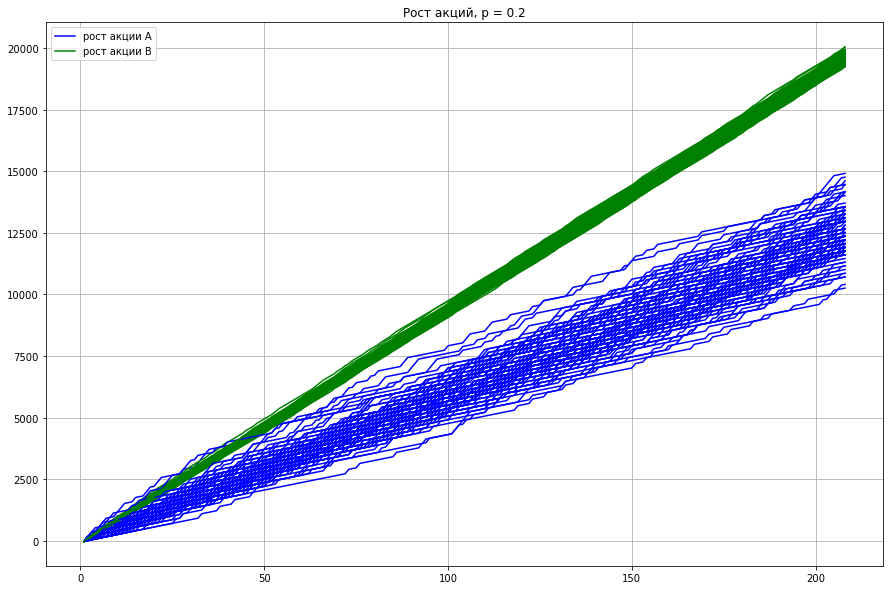

```python
act_A_rise = [180, 30]
act_B_rise = [120, 88]
pp = 0.2
n = 100
period = 208
act_A_now = 0
act_B_now = 0
plot_rost_of_act_A_and_b(act_A_rise, act_B_rise, pp, n, period, act_A_now, act_B_now)
```

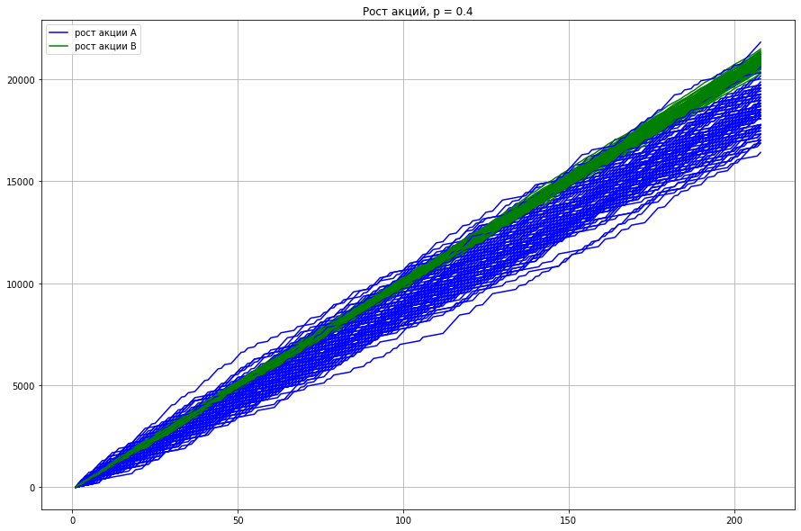

```python
pp = 0.4
plot_rost_of_act_A_and_b(act_A_rise, act_B_rise, pp, n, period, act_A_now, act_B_now)
```

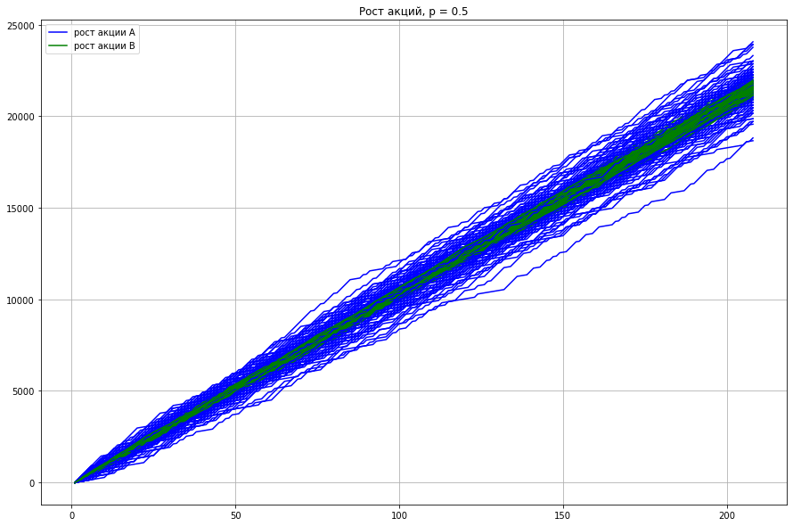

```python
pp = 0.5
plot_rost_of_act_A_and_b(act_A_rise, act_B_rise, pp, n, period, act_A_now, act_B_now)
```

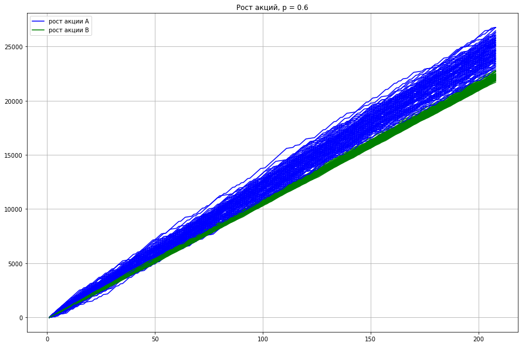

```python
pp = 0.6
plot_rost_of_act_A_and_b(act_A_rise, act_B_rise, pp, n, period, act_A_now, act_B_now)
```

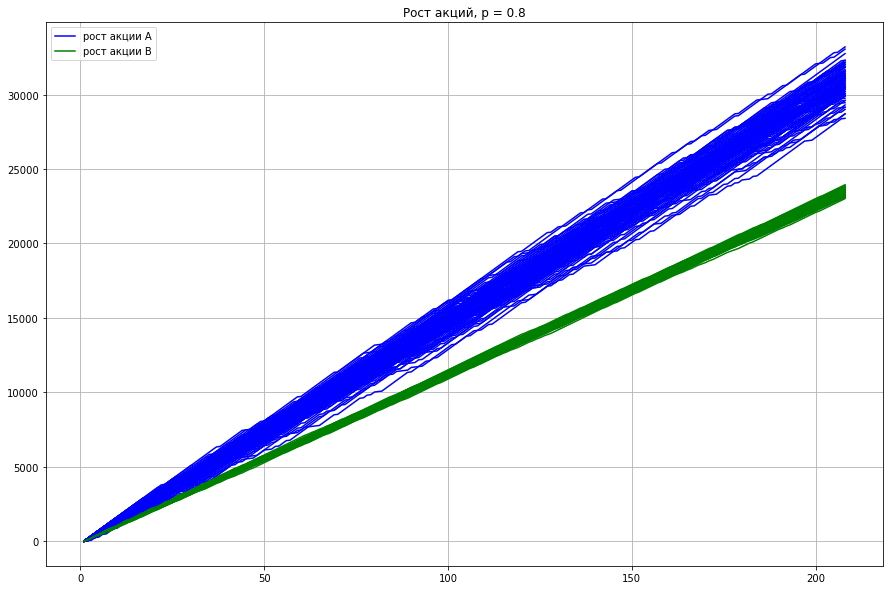

```python
pp = 0.8
plot_rost_of_act_A_and_b(act_A_rise, act_B_rise, pp, n, period, act_A_now, act_B_now)
```

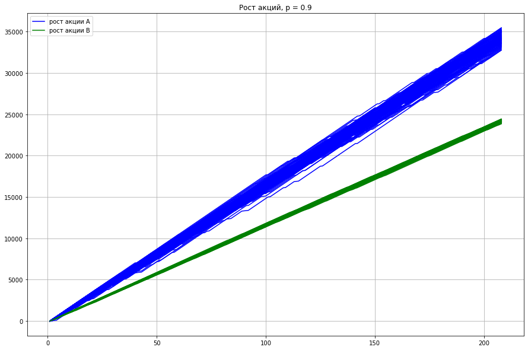

```python
pp = 0.9
plot_rost_of_act_A_and_b(act_A_rise, act_B_rise, pp, n, period, act_A_now, act_B_now)
```

ПУНКТ 2: для того чтобы вывести гипотезу о распределение выборок генеральных совокупностей X и Y, построим гистограммы выборок этих генеральных совокупностей

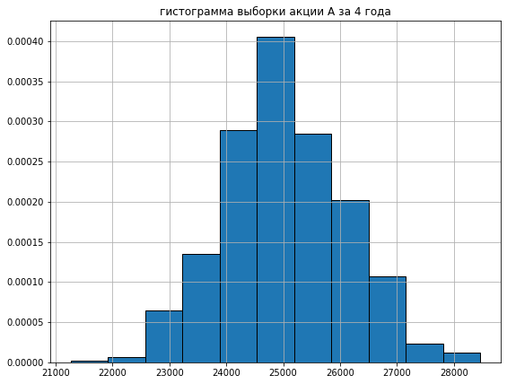

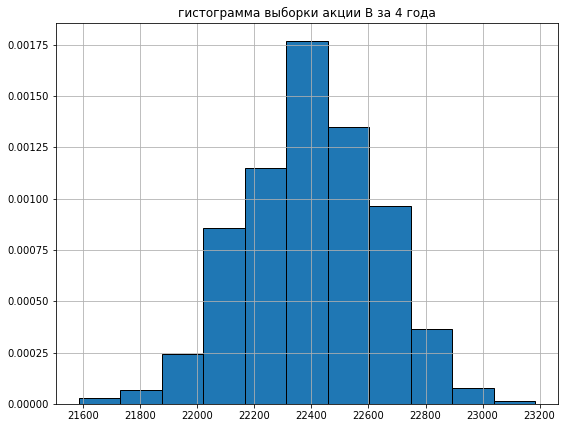

```python
def massivs_X_and_Y(n, pp, Act_A_now, Act_B_now, act_A_rise, act_B_rise):
    X_selection = []
    Y_selection = []

    for k in range(n):
        act_A_now = Act_A_now
        act_B_now = Act_B_now
        for i in range(period - 1):#первая неделя учитывается в начале
            rost_A = np.random.choice(act_A_rise, size = 1, replace = True, p = [pp, 1 - pp])[0]
            rost_B = np.random.choice(act_B_rise, size = 1, replace = True, p = [pp, 1 - pp])[0]
            act_A_now += rost_A
            act_B_now += rost_B
        X_selection.append(act_A_now)
        Y_selection.append(act_B_now)
    return [X_selection, Y_selection]

def plot_2_histograms(X_selection, Y_selection):
    plt.figure(figsize = (9, 7))
    plt.hist(X_selection, bins = 'sturges', edgecolor = 'black', density = True)
    plt.grid(True)
    plt.title("гистограмма выборки акции A за 4 года")
    plt.figure(figsize = (9, 7))
    plt.hist(Y_selection, bins = 'sturges', edgecolor = 'black', density = True)
    plt.grid(True)
    plt.title("гистограмма выборки акции B за 4 года")

pp = 0.6
n = 1000
period = 208
Act_A_now = 200
Act_B_now = 200
act_A_rise = [180, 30]
act_B_rise = [120, 88]
massivs = massivs_X_and_Y(n, pp, Act_A_now, Act_B_now, act_A_rise, act_B_rise)
X_selection = massivs[0]
Y_selection = massivs[1]
plot_2_histograms(X_selection, Y_selection)
```

Из гистограмм можно выдвинуть гипотезу о том что случайные величины X и Y имеют нормальное распределение. Проверим это с помощью критерия Шапиро-Уилка (воспользуемся встроенной функцией sts.shapiro)

```python
stat_znach_X, p_value_X = sts.shapiro(X_selection)
stat_znach_Y, p_value_Y = sts.shapiro(Y_selection)
print("Результат проверки на нормальность ген. совокупности выборки критерием Шапиро-Уилка\n")
print("Выборочное значение статистики:", stat_znach_X)
print("Значение p-value:", p_value_X, "\n")
print("Результат проверки на нормальность ген. совокупности выборки критерием Шапиро-Уилка\n")
print("Выборочное значение статистики:", stat_znach_Y)
print("Значение p-value:", p_value_Y, "\n")
```

```
Результат проверки на нормальность ген. совокупности выборки критерием Шапиро-Уилка

Выборочное значение статистики: 0.9961795806884766
Значение p-value: 0.014710529707372189

Результат проверки на нормальность ген. совокупности выборки критерием Шапиро-Уилка

Выборочное значение статистики: 0.9973230361938477
Значение p-value: 0.09731131792068481
```

ВЫВОД: при $\alpha \lt 0.014710529707372189$ гипотеза о нормальном распределении X принимается, в противном случае - отклоняется. При $\alpha \lt 0.09731131792068481$ гипотеза о нормальном распределении Y принимается, в противном случае - отклоняется

ПУНКТ 3

```python
def characteristics_X_and_Y(n, pp, Act_A_now, Act_B_now, act_A_rise, act_B_rise):
    X_selection = []
    Y_selection = []

    for k in range(n):
        act_A_now = Act_A_now
        act_B_now = Act_A_now
        for i in range(period - 1):#первая неделя учитывается в начале
            rost_A = np.random.choice(act_A_rise, size = 1, replace = True, p = [pp, 1 - pp])[0]
            rost_B = np.random.choice(act_B_rise, size = 1, replace = True, p = [pp, 1 - pp])[0]
            act_A_now += rost_A
            act_B_now += rost_B
        X_selection.append(act_A_now)
        Y_selection.append(act_B_now)

    m_x = np.mean(X_selection)
    m_y = np.mean(Y_selection)
    med_x = np.median(X_selection)
    med_y = np.median(Y_selection)
    return [m_x, m_y, med_x, med_y]

n = 100
period = 208
Act_A_now = 200
Act_B_now = 200
act_A_rise = [180, 30]
act_B_rise = [120, 88]

p_massiv = [0.01*i for i in range(1, 100)]

print("_______ХАРАКТЕРИТИКИ__ПОЛОЖЕНИЯ__ВЫБОРОК__ГЕНЕРАЛЬНЫХ__СОВОКУПНОСТЕЙ__X__И__Y__________")
print("_______________________________________________________________________________________")
print("ЗНАЧЕНИЕ_p___выборочное_m_X_____выборочное_m_Y_____РАЗНИЦА_МЕЖДУ_m_X_и_m_Y_____выборочн_медиана_X___выборочн_медиана_X____РАЗНИЦА_МЕЖДУ_МЕДИАНАМИ")
for p in p_massiv:
    parameters = characteristics_X_and_Y(n, p, Act_A_now, Act_B_now, act_A_rise, act_B_rise)
    print(round(p, 2), "\t \t ", parameters[0], "\t", parameters[1], "\t \t", round(np.abs(parameters[0] - parameters[1]), 3), "\t \t \t", parameters[2], "\t \t", parameters[3], "\t \t", round(np.abs(parameters[2] - parameters[3]), 3))
```

```
_______ХАРАКТЕРИТИКИ__ПОЛОЖЕНИЯ__ВЫБОРОК__ГЕНЕРАЛЬНЫХ__СОВОКУПНОСТЕЙ__X__И__Y__________
_______________________________________________________________________________________
ЗНАЧЕНИЕ_p___выборочное_m_X_____выборочное_m_Y_____РАЗНИЦА_МЕЖДУ_m_X_и_m_Y_____выборочн_медиана_X___выборочн_медиана_X____РАЗНИЦА_МЕЖДУ_МЕДИАНАМИ
0.01 	 	  6708.5 	 18482.88 	 	 11774.38 	 	 	 6710.0 	 	 18480.0 	 	 11770.0
0.02 	 	  7001.0 	 18547.52 	 	 11546.52 	 	 	 7010.0 	 	 18544.0 	 	 11534.0
0.03 	 	  7292.0 	 18627.52 	 	 11335.52 	 	 	 7235.0 	 	 18608.0 	 	 11373.0
0.04 	 	  7701.5 	 18680.96 	 	 10979.46 	 	 	 7760.0 	 	 18672.0 	 	 10912.0
0.05 	 	  7958.0 	 18752.0 	 	 10794.0 	 	 	 7910.0 	 	 18736.0 	 	 10826.0
0.06 	 	  8322.5 	 18812.8 	 	 10490.3 	 	 	 8285.0 	 	 18800.0 	 	 10515.0
0.07 	 	  8519.0 	 18884.48 	 	 10365.48 	 	 	 8510.0 	 	 18896.0 	 	 10386.0
0.08 	 	  8879.0 	 18936.96 	 	 10057.96 	 	 	 8810.0 	 	 18928.0 	 	 10118.0
0.09 	 	  9290.0 	 19012.48 	 	 9722.48 	 	 	 9335.0 	 	 18992.0 	 	 9657.0
0.1 	 	  9549.5 	 19063.36 	 	 9513.86 	 	 	 9560.0 	 	 19088.0 	 	 9528.0
0.11 	 	  9833.0 	 19136.64 	 	 9303.64 	 	 	 9860.0 	 	 19120.0 	 	 9260.0
0.12 	 	  10118.0 	 19199.36 	 	 9081.36 	 	 	 10235.0 	 	 19184.0 	 	 8949.0
0.13 	 	  10479.5 	 19295.04 	 	 8815.54 	 	 	 10460.0 	 	 19280.0 	 	 8820.0
0.14 	 	  10716.5 	 19337.28 	 	 8620.78 	 	 	 10760.0 	 	 19344.0 	 	 8584.0
0.15 	 	  11006.0 	 19412.16 	 	 8406.16 	 	 	 11060.0 	 	 19408.0 	 	 8348.0
0.16 	 	  11453.0 	 19481.28 	 	 8028.28 	 	 	 11510.0 	 	 19472.0 	 	 7962.0
0.17 	 	  11715.5 	 19517.12 	 	 7801.62 	 	 	 11660.0 	 	 19536.0 	 	 7876.0
0.18 	 	  12089.0 	 19619.2 	 	 7530.2 	 	 	 12110.0 	 	 19600.0 	 	 7490.0
0.19 	 	  12354.5 	 19680.64 	 	 7326.14 	 	 	 12260.0 	 	 19696.0 	 	 7436.0
0.2 	 	  12462.5 	 19725.44 	 	 7262.94 	 	 	 12410.0 	 	 19728.0 	 	 7318.0
0.21 	 	  13052.0 	 19818.56 	 	 6766.56 	 	 	 13010.0 	 	 19792.0 	 	 6782.0
0.22 	 	  13349.0 	 19883.2 	 	 6534.2 	 	 	 13460.0 	 	 19856.0 	 	 6396.0
0.23 	 	  13449.5 	 19920.64 	 	 6471.14 	 	 	 13460.0 	 	 19920.0 	 	 6460.0
0.24 	 	  13788.5 	 20010.88 	 	 6222.38 	 	 	 13760.0 	 	 19984.0 	 	 6224.0
0.25 	 	  14132.0 	 20088.64 	 	 5956.64 	 	 	 14210.0 	 	 20112.0 	 	 5902.0
0.26 	 	  14426.0 	 20122.88 	 	 5696.88 	 	 	 14360.0 	 	 20112.0 	 	 5752.0
0.27 	 	  14564.0 	 20236.8 	 	 5672.8 	 	 	 14510.0 	 	 20224.0 	 	 5714.0
0.28 	 	  15233.0 	 20244.16 	 	 5011.16 	 	 	 15260.0 	 	 20208.0 	 	 4948.0
0.29 	 	  15375.5 	 20348.8 	 	 4973.3 	 	 	 15410.0 	 	 20336.0 	 	 4926.0
0.3 	 	  15828.5 	 20413.44 	 	 4584.94 	 	 	 15785.0 	 	 20400.0 	 	 4615.0
0.31 	 	  16043.0 	 20475.2 	 	 4432.2 	 	 	 16010.0 	 	 20464.0 	 	 4454.0
0.32 	 	  16298.0 	 20494.72 	 	 4196.72 	 	 	 16460.0 	 	 20464.0 	 	 4004.0
0.33 	 	  16704.5 	 20598.08 	 	 3893.58 	 	 	 16910.0 	 	 20576.0 	 	 3666.0
0.34 	 	  17037.5 	 20633.92 	 	 3596.42 	 	 	 17060.0 	 	 20624.0 	 	 3564.0
0.35 	 	  17279.0 	 20809.92 	 	 3530.92 	 	 	 17360.0 	 	 20816.0 	 	 3456.0
0.36 	 	  17444.0 	 20759.68 	 	 3315.68 	 	 	 17435.0 	 	 20752.0 	 	 3317.0
0.37 	 	  17873.0 	 20843.2 	 	 2970.2 	 	 	 17960.0 	 	 20832.0 	 	 2872.0
```

[output cut: 47 more lines]

```
0.85 	 	  32777.0 	 24048.0 	 	 8729.0 	 	 	 32810.0 	 	 24048.0 	 	 8762.0
0.86 	 	  33201.5 	 24135.68 	 	 9065.82 	 	 	 33260.0 	 	 24144.0 	 	 9116.0
0.87 	 	  33362.0 	 24183.04 	 	 9178.96 	 	 	 33260.0 	 	 24176.0 	 	 9084.0
0.88 	 	  33693.5 	 24266.56 	 	 9426.94 	 	 	 33710.0 	 	 24272.0 	 	 9438.0
0.89 	 	  34044.5 	 24295.36 	 	 9749.14 	 	 	 34010.0 	 	 24304.0 	 	 9706.0
0.9 	 	  34404.5 	 24395.84 	 	 10008.66 	 	 	 34460.0 	 	 24400.0 	 	 10060.0
0.91 	 	  34622.0 	 24435.52 	 	 10186.48 	 	 	 34610.0 	 	 24464.0 	 	 10146.0
0.92 	 	  34997.0 	 24531.2 	 	 10465.8 	 	 	 34985.0 	 	 24528.0 	 	 10457.0
0.93 	 	  35325.5 	 24596.48 	 	 10729.02 	 	 	 35360.0 	 	 24592.0 	 	 10768.0
0.94 	 	  35597.0 	 24644.48 	 	 10952.52 	 	 	 35660.0 	 	 24656.0 	 	 11004.0
0.95 	 	  35817.5 	 24696.96 	 	 11120.54 	 	 	 35810.0 	 	 24720.0 	 	 11090.0
0.96 	 	  36209.0 	 24777.6 	 	 11431.4 	 	 	 36260.0 	 	 24784.0 	 	 11476.0
0.97 	 	  36513.5 	 24845.76 	 	 11667.74 	 	 	 36560.0 	 	 24848.0 	 	 11712.0
0.98 	 	  36809.0 	 24901.76 	 	 11907.24 	 	 	 36860.0 	 	 24912.0 	 	 11948.0
0.99 	 	  37142.0 	 24973.44 	 	 12168.56 	 	 	 37160.0 	 	 24976.0 	 	 12184.0
```

ВЫВОД: можно сказать, что при $p \in [0.49, 0.5]$ случайные величины $X$ и $Y$ будут наиболее близки по характеристикам положения.